# Auditory Distance Perception Study Power Analysis

Lucas Gonzalez - Damian Payo - Manuel Eguia

26/9/2023

## Abstract

Present the analysis of results obtained from PAD experiment in September 2023 in two locations: first, in a small room named “Gessel Camera” at the Catholic University of Salta (28 subjects) and, secondly, in room 27 of the National University of Quilmes (41 subjetcs).

**The experience** use 4 listening blocks with 4 conditions:  
- *Wideband or Unfiltered (WW)*: The original stimuli (white noise with a duration of 0.3s) with no filtering applied.  
- *Low-Pass Filtered (LL)*: the stimuli with a low-pass filter applied, set at 1 kHz.  
- *Direct Part Low-Pass Filtered and Reverberant Part Unfiltered (LW)*: Only the direct portion of the stimuli is affected by a low-pass filter, with a critical frequency of 1 kHz.  
- *Direct Part Unfiltered and Reverberant Part Low-Pass Filtered (WL)*: Only the reverberant portion of the stimuli is affected by a low-pass filter with a critical frequency of 1kHz.  
Each block is separated by one minute of rest. between block the subjects would see a recreation (360 degree image) of the room through a VR headset.

## Data Loading

There are 276 .csv files corresponding to each condition/block for each subject.  
- “nsub” is the ID given to the subject  
- “dist_log” corresponds to the actual distance of the sound stimulus. It can contain 12 values.  
- “resp_log” is the subject’s response to the stimulus  
- “bloque” is not the actual data of the block order. It will be corrected later.

```r
# Corregimos la columna de condicion con una etiqueta mas legible
data_1k_DR$condicion[data_1k_DR$condicion==0] <- "WW"
data_1k_DR$condicion[data_1k_DR$condicion==1] <- "LL"
data_1k_DR$condicion[data_1k_DR$condicion==2] <- "LW"
data_1k_DR$condicion[data_1k_DR$condicion==3] <- "WL"

orden_bloques <- read.csv("./orden_bloques.csv")
data_1k_DR <- merge(x=orden_bloques,y=data_1k_DR,
                             by=c("nsub","condicion"))

# Erase redundant columns
data_1k_DR <- data_1k_DR[, !names(data_1k_DR) %in% c("bloque","altura")]

rm(orden_bloques)
```

## Log-Log Distance-Responses

We apply logarithms to the response and distance observations in order to make linear regressions between the variables and obtain a slope indicating distance compression

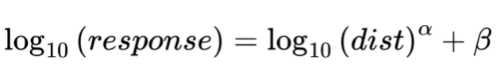

## Outlier Detection and Removal by Response

We applied the *Minimum Covariance Determinant* criteria to detect multivariate outliers.

Before that, we eliminate 3 subjects due to the responses being incomplete.

We eliminated 1959 observations from the total of 9915 with this method.

## Linear Regressions

We performed a linear regression for each condition per subject. We generate a new tibble containing a slope value for each condition per subject (nsub).

If slope is 1, it means that the compression ratio is 1 to 1, it means that there is no compression. If it is higher than 1, it means that there is expansion. If it is less than 1, it means that there is distance compression.

In addition, all the residuals (distance to linear regression) are put together in a vector (sresids). Finally, a variable is added with the order of the blocks by appearance during the experiment (order).

## Subject dismissal

Before the evaluation, subjects were asked to complete a form with demographic information. Subject number 4 expressed hearing impairment in one ear and subjetcs number 56 and 69 expressed tinitus. So we decided to exclude there data from the analysis.

### Observation of normality in residuals

We plotted a histogram and qqplot with the residuals of the linear regression performed for each subject.

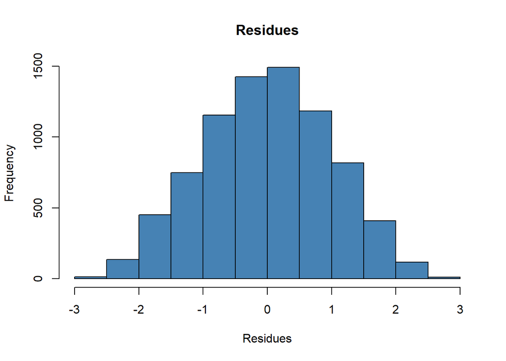

```r
# Histogram & QQ Plot
hist(sresids, col='steelblue', main='Residues',xlab="Residues")
```

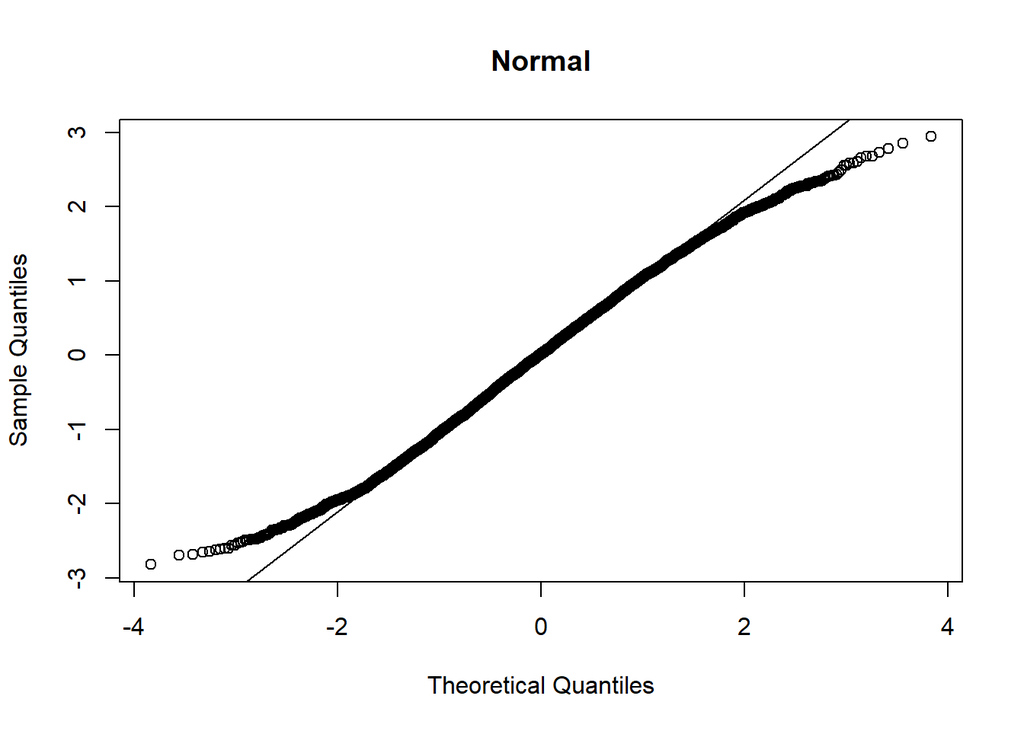

```r
qqnorm(sresids, main='Normal')
qqline(sresids)
```

### Intrasubject residuals normality test

We performed an analysis of the normality of the intrasubject residuals with the Shapiro.Wilk method. The study compares subjects (nsubs) according to condition, reporting which ones do not allow us to approve the Null Hypothesis (H0) that residuals come from a normal distribution.

```r
normality_test <- data_clean %>%
  group_by(nsub, condicion) %>%
  summarise(statistic = shapiro.test(res)$statistic,
            p.value = shapiro.test(res)$p.value)

normality_test%>%subset(p.value<0.05)
```

```
## # A tibble: 8 × 4
## # Groups:   nsub [8]
##    nsub condicion statistic p.value
##   <int> <chr>         <dbl>   <dbl>
## 1     6 LW            0.927 0.0407
## 2    13 LW            0.937 0.0413
## 3    19 LL            0.913 0.0476
## 4    22 WL            0.926 0.0496
## 5    35 WL            0.912 0.0331
## 6    39 LW            0.886 0.0270
## 7    48 LL            0.885 0.00720
## 8    68 WW            0.905 0.0282
```

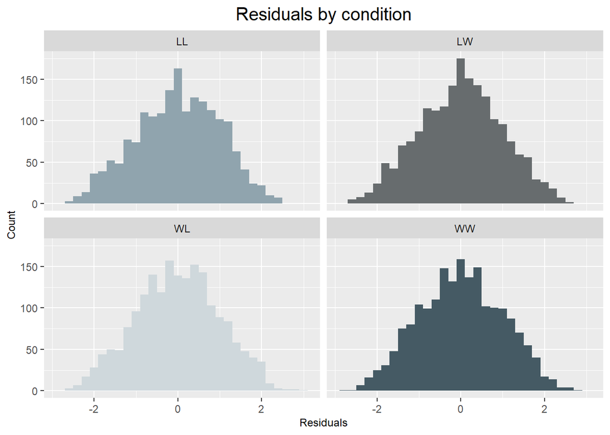

```r
## residuos ploteados en dos ejes, para poder ver la variabilidad por
## distancia por condicion por frecuencia.6 figuras en total
cols <- c("#455A64", "#90A4AE", "#CFD8DC",  "#676c6e")

ggplot(data_clean, aes(x = res, fill = condicion)) +
  geom_histogram(binwidth = 0.2) +
  scale_fill_manual(values = cols,
                    limits = c('WW', 'LL', 'WL', 'LW'),
                    labels = c('Wide', 'Low', 'Wide-Low', 'Low-Wide'),
                    guide = guide_none()) + # Para ocultar las etiquetas de la leyenda
  labs(y = 'Count', x = "Residuals") +  # Para quitar las etiquetas del eje y
  labs(title = 'Residuals by condition') +  # Para quitar el título de los gráficos facetados
  facet_wrap(~condicion, labeller = "label_value") +
  theme(axis.title.x = element_text(size = 9),
        axis.title.y = element_text(size = 9),
        plot.title = element_text(size = 15, hjust = 0.5))
```

### Outliers by Slopes and Incomplete subjects filtering

We applied the MAD (robust median absolute deviation) criterion to eliminate univariate outliers corresponding to the slopes.

Then we eliminate from the table the subjects without an observation for each condition.

```r
slope_1k_WW <- data_slopes %>% filter(condicion=="WW")
slope_1k_LL <- data_slopes %>% filter(condicion=="LL")
slope_1k_WL <- data_slopes %>% filter(condicion=="WL")
slope_1k_LW <- data_slopes %>% filter(condicion=="LW")

# 1k
outliers <-outliers_mad(slope_1k_WW$slope)
#outliers$limits[2]
slope_1k_WW<- slope_1k_WW[slope_1k_WW$slope<outliers$limits[2],]

outliers <-outliers_mad(slope_1k_LL$slope)
#outliers$limits[2]
slope_1k_LL<- slope_1k_LL[slope_1k_LL$slope<outliers$limits[2],]

outliers <-outliers_mad(slope_1k_WL$slope)
#outliers$limits[2]
slope_1k_WL<- slope_1k_WL[slope_1k_WL$slope<outliers$limits[2],]

outliers <-outliers_mad(slope_1k_LW$slope)
#outliers$limits[2]
slope_1k_LW<- slope_1k_LW[slope_1k_LW$slope<outliers$limits[2],]


data_slopes_clean <- (rbind(slope_1k_LL,slope_1k_WW,
                            slope_1k_LW,slope_1k_WL))

count_conditions <- data_slopes_clean %>%
  group_by(nsub) %>%
  summarise(n = n())
drops <- count_conditions %>% subset(n!=4)

data_slopes_clean <- data_slopes_clean[!(data_slopes_clean$nsub%in%
                                                 drops$nsub), ]

data_clean <- data_clean[!(data_clean$nsub%in%
                             drops$nsub), ]

rm(count_conditions, outliers)
rm(slope_1k_LL, slope_1k_WW, slope_1k_LW, slope_1k_WL)
```

### Normality Test Slopes

We apply Shapiro-Wilk to check if data can come from a normal distribution. In this case, the data without a normal distribution are those corresponding to the “Low-Wide” condition.

```r
normality_slopes <- data_slopes_clean %>%
  group_by(freq, condicion) %>%
  summarise(statistic = shapiro.test(slope)$statistic,
            p.value = shapiro.test(slope)$p.value,
            normality=(p.value>0.05))

normality_slopes
```

```
## # A tibble: 4 × 5
## # Groups:   freq [1]
##   freq  condicion statistic p.value normality
##   <chr> <chr>         <dbl>   <dbl> <lgl>
## 1 1k    LL            0.970 0.145   TRUE
## 2 1k    LW            0.937 0.00375 FALSE
## 3 1k    WL            0.986 0.726   TRUE
## 4 1k    WW            0.987 0.783   TRUE
```

## Slopes Boxplot

We plotted in a boxplot the total slopes per condition, noting the degree of significance in the data.

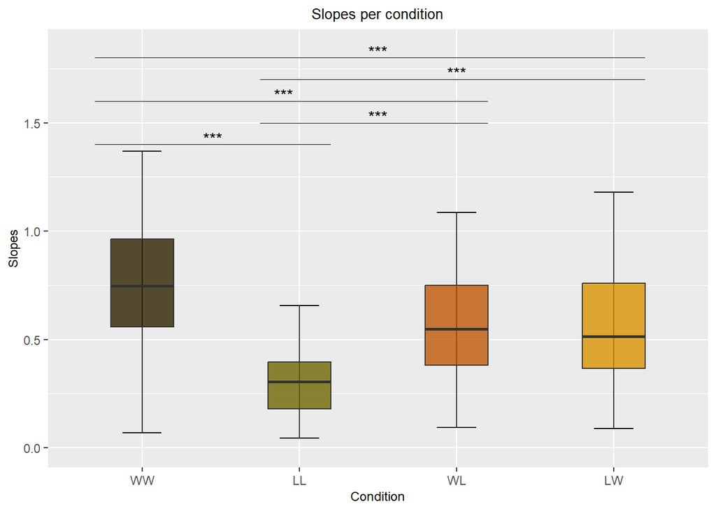

```r
#cols <- c("#505160", "#68829E", "#AEBD38", "#598234")
cols <- c("#2E2300", "#6E6702", "#C05805", "#DB9501")


plt_1k_slope <- ggplot(data_slopes_clean,
                       aes(x=condicion, y=slope, fill=condicion)) +
  stat_boxplot(geom = "errorbar",
               width = 0.25) +
  geom_boxplot(alpha=0.8, outlier.colour=NA, width = 0.4)+
   scale_fill_manual(values = cols,
                    limits = c('WW', 'LL', 'WL', 'LW'),
                    labels = c('Wide', 'Low', 'Wide-Low', 'Low-Wide'),
                    guide = guide_none()) +
  scale_y_continuous(limits=c(0, 1.84)) +
  scale_x_discrete(limits = c('WW', 'LL', 'WL', 'LW')) +
  labs(title="Slopes per condition", y='Slopes', x='Condition')+
 # WW- LW
  annotate("text", x = 2.5, y = 1.83,  label = "***", size = 4) +
  annotate("segment", x = 0.7, xend = 4.2, y = 1.8,
            yend = 1.8, colour = "black", size=.2, alpha=1,) +
  # LL - LW
  annotate("text", x = 3, y = 1.73,  label = "***", size = 4) +
  annotate("segment", x = 1.75, xend = 4.2, y = 1.7,
            yend = 1.7, colour = "black", size=.2, alpha=1,) +
  # WW- WL
  annotate("text", x = 1.9, y = 1.63,  label = "***", size = 4) +
  annotate("segment", x = 0.7, xend = 3.2, y = 1.6,
            yend = 1.6, colour = "black", size=.2, alpha=1,) +
  # LL - WL
   annotate("text", x = 2.5, y = 1.53,  label = "***", size = 4) +
   annotate("segment", x = 1.75, xend = 3.2, y = 1.5,
            yend = 1.5, colour = "black", size=.2, alpha=1,) +
  #WW - LL
   annotate("text", x = 1.45, y = 1.43,  label = "***", size = 4) +
   annotate("segment", x = 0.7, xend = 2.2, y = 1.4,
            yend = 1.4, colour = "black", size=.2, alpha=1,) +
  theme(axis.title.x = element_text(size = 9),
        axis.title.y = element_text(size = 9),
        plot.title = element_text(size = 10, hjust = 0.5))
plt_1k_slope
```

### Regressions Plot

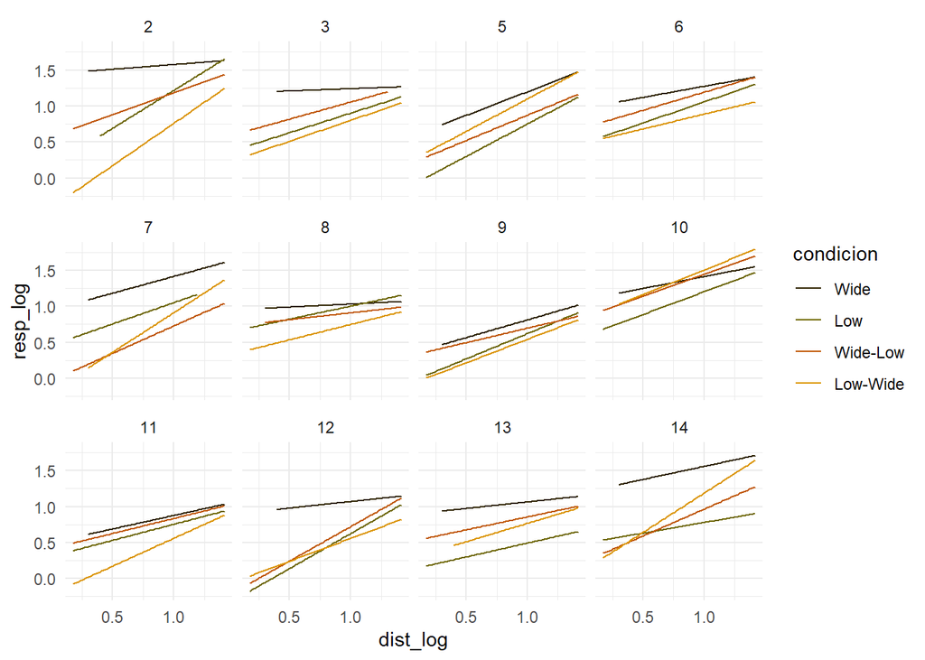

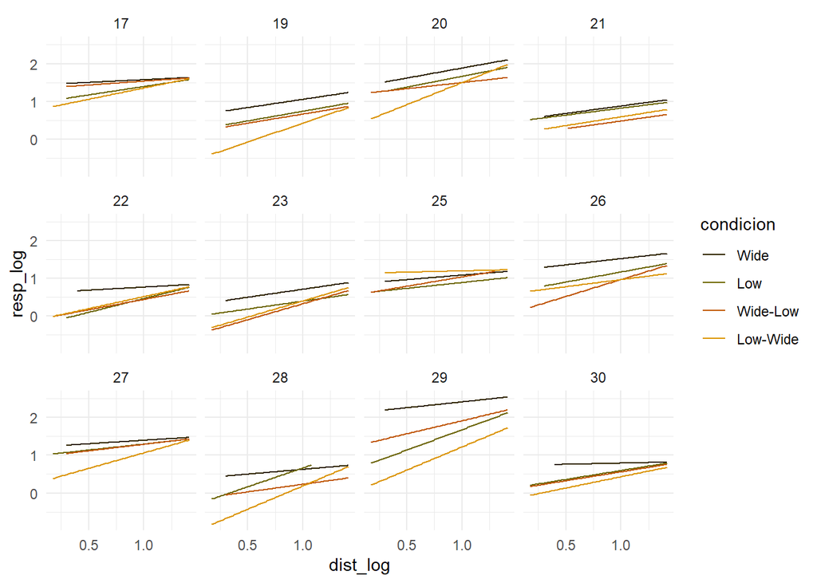

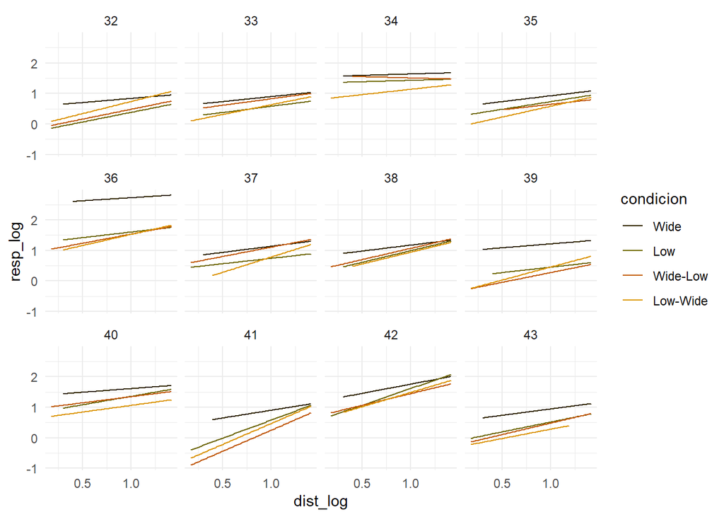

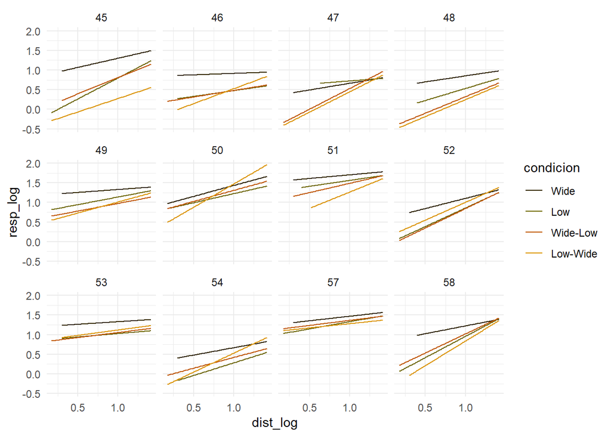

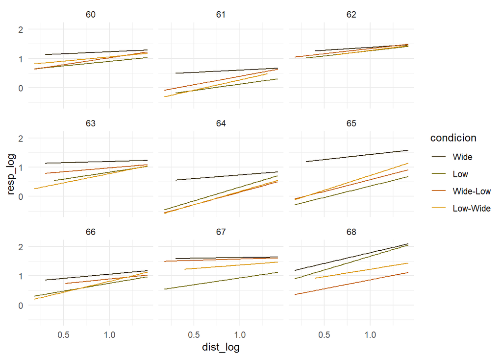

### data_prom tibble with means and std per condition

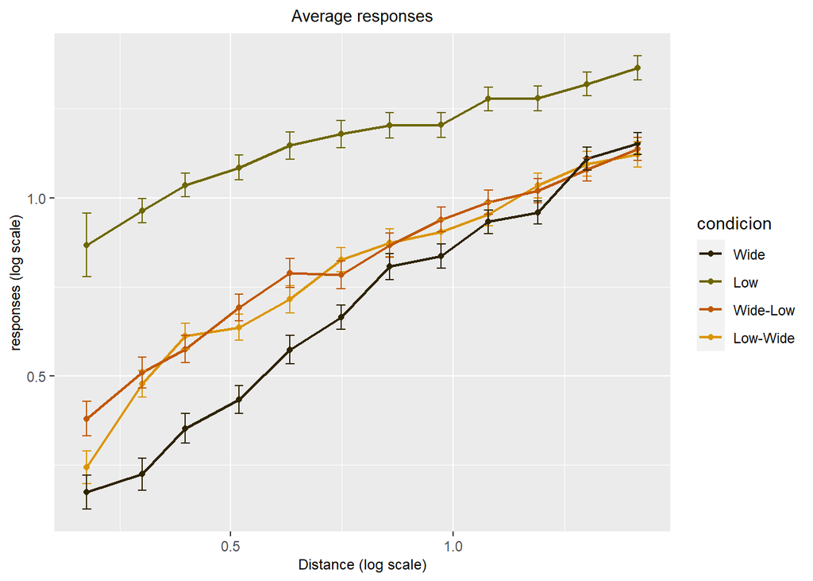

```r
data_prom <- data_clean %>%
  group_by(condicion, dist_log) %>%
  summarise(dist_log,
            resp_log,
            prom_log = mean(resp_log),
            sd_log = sd(resp_log),
            std_log = std.error(resp_log))

ggplot(data_prom,
       aes(x=dist_log, y=prom_log,
           color = condicion)) +
  geom_point() +
  geom_line(linewidth = 0.8) +
  scale_color_manual(values = cols,
                    limits = c('WW', 'LL', 'WL', 'LW'),
                    labels = c('Wide', 'Low', 'Wide-Low', 'Low-Wide')) +
  geom_errorbar(aes(ymin=prom_log-std_log,
                    ymax=prom_log+std_log),
                width = 0.02) +
  # facet_grid(rows = vars(ID)) +
  labs(title = "Average responses", x='Distance (log scale)', y='responses (log scale)') +
  theme(axis.title.x = element_text(size = 9),
        axis.title.y = element_text(size = 9),
        plot.title = element_text(size = 10, hjust = 0.5))
```

## Mixed Design Model

This analysis allows to evaluate the variation of slopes between intrasubject conditions.

[Reference](https://www.youtube.com/watch?v=AWInLxpiZuA)

### One way Anova with reapeated measures

```r
lmer.1k <- lmer(slope ~ condicion + (1|nsub),
    data = data_slopes_clean)
summary(lmer.1k)
```

```
## Linear mixed model fit by REML. t-tests use Satterthwaite's method [
## lmerModLmerTest]
## Formula: slope ~ condicion + (1 | nsub)
##    Data: data_slopes_clean
##
## REML criterion at convergence: -6.5
##
## Scaled residuals:
##      Min       1Q   Median       3Q      Max
## -2.56847 -0.53249  0.01098  0.57245  2.30734
##
## Random effects:
##  Groups   Name        Variance Std.Dev.
##  nsub     (Intercept) 0.03022  0.1738
##  Residual             0.03703  0.1924
## Number of obs: 244, groups:  nsub, 61
##
## Fixed effects:
##              Estimate Std. Error        df t value Pr(>|t|)
## (Intercept)   0.29713    0.03321 149.45789   8.948 1.30e-15 ***
## condicionLW   0.27928    0.03485 180.00000   8.015 1.35e-13 ***
## condicionWL   0.26413    0.03485 180.00000   7.580 1.76e-12 ***
## condicionWW   0.44648    0.03485 180.00000  12.813  < 2e-16 ***
## ---
## Signif. codes:  0 '***' 0.001 '**' 0.01 '*' 0.05 '.' 0.1 ' ' 1
##
## Correlation of Fixed Effects:
##             (Intr) cndcLW cndcWL
## condicionLW -0.525
## condicionWL -0.525  0.500
## condicionWW -0.525  0.500  0.500
```

```r
anova(lmer.1k)
```

```
## Type III Analysis of Variance Table with Satterthwaite's method
##           Sum Sq Mean Sq NumDF DenDF F value    Pr(>F)
## condicion 6.2303  2.0768     3   180  56.077 < 2.2e-16 ***
## ---
## Signif. codes:  0 '***' 0.001 '**' 0.01 '*' 0.05 '.' 0.1 ' ' 1
```

```r
##partial eta sq
effectsize::eta_squared(lmer.1k, partial = TRUE)
```

```
## # Effect Size for ANOVA (Type III)
##
## Parameter | Eta2 (partial) |       95% CI
## -----------------------------------------
## condicion |           0.48 | [0.40, 1.00]
##
## - One-sided CIs: upper bound fixed at [1.00].
```

```r
#Rsq
r.squaredGLMM(lmer.1k)
```

```
##           R2m       R2c
## [1,] 0.275994 0.6013415
```

```r
emmeans(lmer.1k,
        list(pairwise ~ condicion),
        adjust="bonferroni")
```

```
## $`emmeans of condicion`
##  condicion emmean     SE  df lower.CL upper.CL
##  LL         0.297 0.0332 149    0.232    0.363
##  LW         0.576 0.0332 149    0.511    0.642
##  WL         0.561 0.0332 149    0.496    0.627
##  WW         0.744 0.0332 149    0.678    0.809
##
## Degrees-of-freedom method: kenward-roger
## Confidence level used: 0.95
##
## $`pairwise differences of condicion`
##  1       estimate     SE  df t.ratio p.value
##  LL - LW  -0.2793 0.0348 180  -8.015  <.0001
##  LL - WL  -0.2641 0.0348 180  -7.580  <.0001
##  LL - WW  -0.4465 0.0348 180 -12.813  <.0001
##  LW - WL   0.0151 0.0348 180   0.435  1.0000
##  LW - WW  -0.1672 0.0348 180  -4.798  <.0001
##  WL - WW  -0.1823 0.0348 180  -5.233  <.0001
##
## Degrees-of-freedom method: kenward-roger
## P value adjustment: bonferroni method for 6 tests
```

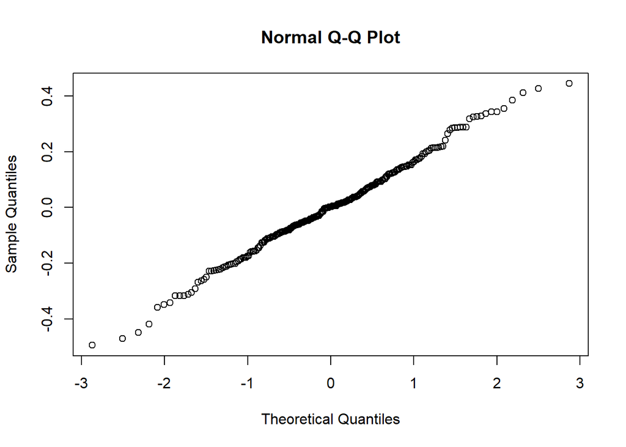

```r
qqnorm(resid(lmer.1k))
```